# statistics-for-machine-learning-final

###### In any data science project, data helps us to analyze the initial level of insight.

## Measures of Central Tendency

### Caculating Mean,Median (Python Code):

```python
import numpy as np
expenditure = np.random.normal(25000, 15000, 10000)
np.mean(expenditure)
```

```
25145.47844894449
```

```python
# Caculating Median:
np.median(expenditure)
```

```
25074.40753341231
```

```python
# Now, we are adding a large number to the sample.
expenditure = np.append(expenditure, [10000000000])

np.median(expenditure)
```

```
25082.11145249947
```

```python
np.mean(expenditure)

# Here, the Median did not change much, but the Mean did.
```

```
1025017.7845622757
```

### Calculating Mode:

Let’s generate a random expenditure set data using the script below.

```python
expenditure = np.random.randint(15, high=50, size=200)
expenditure
```

```
array([36, 44, 40, 21, 48, 43, 38, 18, 24, 33, 29, 30, 24, 20, 30, 20, 43,
       41, 46, 27, 41, 35, 19, 24, 21, 46, 38, 35, 34, 19, 40, 42, 37, 45,
       22, 25, 28, 32, 26, 17, 31, 36, 38, 25, 31, 48, 30, 49, 21, 22, 42,
       31, 38, 43, 44, 23, 26, 42, 26, 30, 30, 37, 22, 46, 46, 48, 37, 28,
       16, 44, 43, 30, 23, 26, 21, 33, 19, 40, 22, 42, 37, 27, 49, 35, 17,
       43, 15, 40, 47, 39, 44, 34, 38, 49, 39, 36, 42, 21, 48, 41, 40, 36,
       44, 23, 32, 33, 21, 47, 23, 15, 30, 47, 40, 45, 49, 30, 16, 29, 38,
       43, 15, 16, 45, 46, 15, 38, 47, 41, 32, 29, 17, 35, 38, 48, 49, 26,
       18, 23, 31, 29, 15, 21, 41, 22, 35, 22, 44, 27, 39, 34, 47, 35, 17,
       18, 36, 41, 19, 21, 40, 20, 18, 25, 47, 28, 32, 35, 38, 46, 36, 18,
       49, 35, 23, 27, 38, 37, 27, 42, 34, 19, 46, 23, 37, 26, 25, 29, 27,
       43, 28, 38, 29, 46, 44, 20, 34, 45, 16, 35, 36, 24])
```

```python
from scipy import stats
stats.mode(expenditure)
```

```
ModeResult(mode=array([38]), count=array([11]))
```

# Measures of Dispersion

## Range

- The difference between the smallest and the largest observations in the sample is called Range.
- For example, the minimum and maximum blood pressure are 113 and 170, respectively. Hence the range is 57.

## Variance:

Variance is a measure of dispersion in a data set.

It is measured by first finding the Deviation of each element in a data set from the mean, and then by squaring it. Variance is an average of all squared deviations.

#### The below figure shows that On an avg how far point is distributed from the mean (x̄)

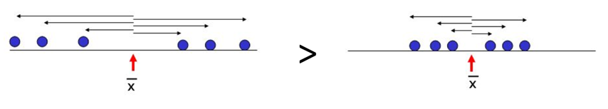

Here(left side) variance is high because, from the mean(x̄), the points are distributed at a longer distance as compared to the right side, where the distance is a bit smaller.

```python
# Q. Consider a list of random integers 3,3,3,5,6,1. We will now calculate the variance using the numpy library.
results = [3,3,3,5,6,1]
np.var(results)
```

```
2.5833333333333335
```

## Standard deviation

• Standard deviation tells us about the concentration of data around the mean of the data set. • Standard deviation (S) is the square root of the variance.

### To measure standard deviation, use the inbuilt function “std” from numpy, as shown below:

```python
np.std(results)
```

```
1.6072751268321592
```

```python
# Using Numpy & Scipy to calculate Mean, Mode, and Median
import numpy as np
from scipy import stats

dataset = [5,5,2,3,4,6,18]

#mean value
mean = np.median(dataset)
#median value
median = np.median(dataset)
#mode value
mode = stats.mode(dataset)

std = np.std(dataset)
vr = np.var(dataset)

print("Mean:", mean)
print("Median:", median)
print("Mode:", mode)
print("STD", std)
print("Var:", vr)
```

```
Mean: 5.0
Median: 5.0
Mode: ModeResult(mode=array([5]), count=array([2]))
STD 4.997958767010258
Var: 24.9795918367347
```

```python
import numpy as np
import pandas as pd
import matplotlib.pyplot as plt
import seaborn as sns
pd.set_option("display.max_columns",None)
pd.set_option("display.max_rows",None)

import warnings
warnings.filterwarnings("ignore")

from IPython.display import Image
from sklearn.preprocessing import StandardScaler
from sklearn.cluster import DBSCAN
from sklearn.neighbors import LocalOutlierFactor
sns.set(style="darkgrid", palette="pastel", color_codes=True)
sns.set_context('talk')

from pathlib import Path
```

## Symmetrical and asymmetrical distribution

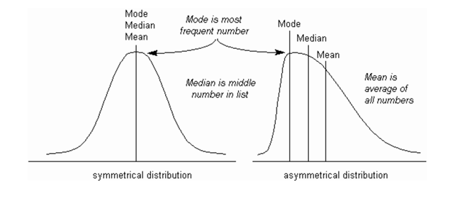

# Skewness

**Skewness:** Skewness is defined as a measure of the dataset’s symmetry. A perfectly symmetrical data set will have zero skewness.

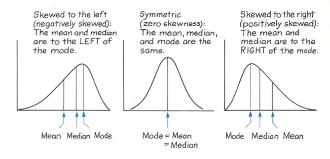

If the mode exceeds the median and mean (Mean < Median < Mode) then the distribution is negatively skewed. Thus, the coefficient of skewness will be negative and the distribution will be skewed to the left.

```python
import seaborn as sns
import numpy as np
import pandas as pd
import matplotlib.pyplot as plt
import plotly.express as px
import seaborn as sns
from scipy.stats import norm
```

```python
df = pd.read_csv('PanelData.csv')
df.head()
```

|  | I | T | C | Q | PF | LF |
| --- | --- | --- | --- | --- | --- | --- |
| 0 | 1 | 1 | 1140640 | 0.952757 | 106650 | 0.534487 |
| 1 | 1 | 2 | 1215690 | 0.986757 | 110307 | 0.532328 |
| 2 | 1 | 3 | 1309570 | 1.091980 | 110574 | 0.547736 |
| 3 | 1 | 4 | 1511530 | 1.175780 | 121974 | 0.540846 |
| 4 | 1 | 5 | 1676730 | 1.160170 | 196606 | 0.591167 |

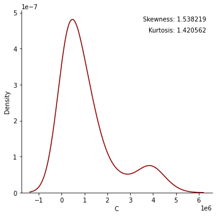

```python
g = sns.displot(data=df, x="C",kind ='kde',color='darkred')
for ax in g.axes.ravel():
    ax.text(x=0.97, y=0.97, transform=ax.transAxes, s="Skewness: %f" % df['C'].skew(),\
        fontsize=10, verticalalignment='top', horizontalalignment='right')
    ax.text(x=0.97, y=0.91, transform=ax.transAxes, s="Kurtosis: %f" % df['C'].kurt(),\
        fontsize=10, verticalalignment='top', horizontalalignment='right')
```

# What are outliers?

## What is the impact of Outliers on a dataset?

#### Outliers can drastically change the results of the data analysis and statistical modeling. There are numerous unfavourable impacts of outliers in the data set:

#### - It increases the error variance and reduces the power of statistical tests

#### - If the outliers are non-randomly distributed, they can decrease normality

#### To understand the impact deeply, let’s take an example to check what happens to a data set with and without outliers in the data set.

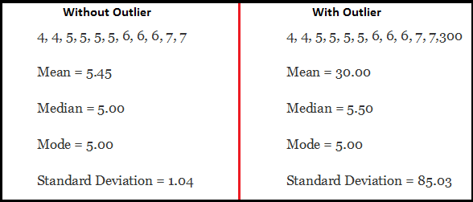

```python
#Image(filename=data_dir/'O6.png')
```

# Outlier Detection Techniques:

```python
df_1= pd.read_csv("StudentsPerformance.csv")
```

```python
df_1.head()
```

|  | gender | race/ethnicity | parental level of education | lunch | test preparation course | math score | reading score | writing score |
| --- | --- | --- | --- | --- | --- | --- | --- | --- |
| 0 | female | group B | bachelor's degree | standard | none | 72 | 72 | 74 |
| 1 | female | group C | some college | standard | completed | 69 | 90 | 88 |
| 2 | female | group B | master's degree | standard | none | 90 | 95 | 93 |
| 3 | male | group A | associate's degree | free/reduced | none | 47 | 57 | 44 |
| 4 | male | group C | some college | standard | none | 76 | 78 | 75 |

```python
df_1.isnull().sum()
```

```
gender                         0
race/ethnicity                 0
parental level of education    0
lunch                          0
test preparation course        0
math score                     0
reading score                  0
writing score                  0
dtype: int64
```

#### There are no null values in the data frame

```python
df_1.describe()
```

|  | math score | reading score | writing score |
| --- | --- | --- | --- |
| count | 1000.00000 | 1000.000000 | 1000.000000 |
| mean | 66.08900 | 69.169000 | 68.054000 |
| std | 15.16308 | 14.600192 | 15.195657 |
| min | 0.00000 | 17.000000 | 10.000000 |
| 25% | 57.00000 | 59.000000 | 57.750000 |
| 50% | 66.00000 | 70.000000 | 69.000000 |
| 75% | 77.00000 | 79.000000 | 79.000000 |
| max | 100.00000 | 100.000000 | 100.000000 |

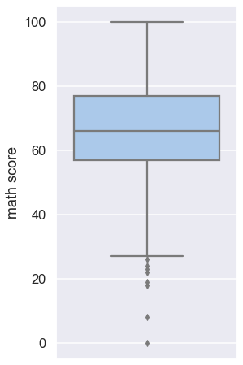

```python
plt.figure(figsize = (4,8))
sns.boxplot(y = df_1['math score'])
```

#### From the above box plot, we can surely observe that there are outliers in it!

# 1) Interquartile Range Method

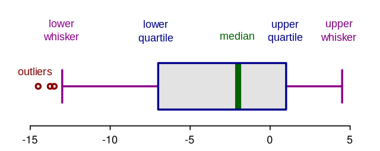

```python
#Image(filename=data_dir/'O3.png')
```

#### Let's define a function to find out the IQR, lower and the upper whisker.

```python
def out_iqr(df , column):
    global lower,upper
    q25, q75 = np.quantile(df[column], 0.25), np.quantile(df[column], 0.75)
    # calculate the IQR
    iqr = q75 - q25
    # calculate the outlier cutoff
    cut_off = iqr * 1.5
    # calculate the lower and upper bound value
    lower, upper = q25 - cut_off, q75 + cut_off
    print('The IQR is',iqr)
    print('The lower bound value is', lower)
    print('The upper bound value is', upper)
    # Calculate the number of records below and above lower and above bound value respectively
    df1 = df[df[column] > upper]
    df2 = df[df[column] < lower]
    return print('Total number of outliers are', df1.shape[0]+ df2.shape[0])
```

```python
out_iqr(df_1,'math score')
```

```
The IQR is 20.0
The lower bound value is 27.0
The upper bound value is 107.0
Total number of outliers are 8
```

### Remedial Measure:

```python
#Data Frame without outliers
df_new = df_1[(df_1['math score'] < upper) | (df_1['math score'] > lower)]
```

# 2) Standard Deviation Method

#### Standard deviation is a metric of variance i.e. how much the individual data points are spread out from the mean. In statistics, If a data distribution is approximately normal then about 68% of the data values lie within one standard deviation of the mean and about 95% are within two standard deviations, and about 99.7% lie within three standard deviations

#### For example, I'll take up the [Student Performance in Exam DataSet](https://www.kaggle.com/spscientist/students-performance-in-exams) for explaining SDM.

```python
df_2 = pd.read_csv("StudentsPerformance.csv")
df_2.head()
```

|  | gender | race/ethnicity | parental level of education | lunch | test preparation course | math score | reading score | writing score |
| --- | --- | --- | --- | --- | --- | --- | --- | --- |
| 0 | female | group B | bachelor's degree | standard | none | 72 | 72 | 74 |
| 1 | female | group C | some college | standard | completed | 69 | 90 | 88 |
| 2 | female | group B | master's degree | standard | none | 90 | 95 | 93 |
| 3 | male | group A | associate's degree | free/reduced | none | 47 | 57 | 44 |
| 4 | male | group C | some college | standard | none | 76 | 78 | 75 |

#### Let's consider the "writing score" for inspection. I'll plot a simple density plot which is also one of the best visualization for detecting outliers

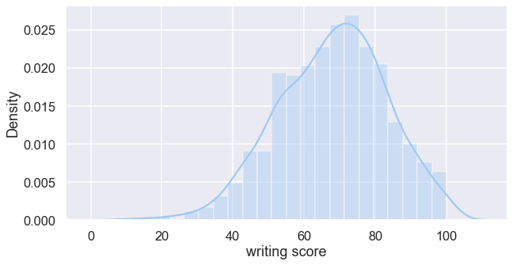

```python
plt.figure(figsize = (10,5))
sns.distplot(df_2['writing score'])
```

#### By the looks of it, it is left tailed and it surely has outliers.

#### Let's define a function to find out the lower and the upper whisker using SDM:

```python
def out_std(df, column):
    global lower,upper
    # calculate the mean and standard deviation of the data frame
    data_mean, data_std = df[column].mean(), df[column].std()
    # calculate the cutoff value
    cut_off = data_std * 3
    # calculate the lower and upper bound value
    lower, upper = data_mean - cut_off, data_mean + cut_off
    print('The lower bound value is', lower)
    print('The upper bound value is', upper)
    # Calculate the number of records below and above lower and above bound value respectively
    df1 = df[df[column] > upper]
    df2 = df[df[column] < lower]
    return print('Total number of outliers are', df1.shape[0]+ df2.shape[0])
```

```python
out_std(df_2,'writing score')
```

```
The lower bound value is 22.467028967391073
The upper bound value is 113.64097103260893
Total number of outliers are 4
```

### So as per the SD method, there are 4 ouliters

### Remedial Measure:

```python
#Data Frame without outliers
df_new = df_2[(df_2['writing score'] < upper) | (df_2['writing score'] > lower)]
```

# 3) Z-Score method:

#### For example, I'll take up the [TMedical Cost Personal Datasets](https://www.kaggle.com/mirichoi0218/insurance) for explaining Z-Score method.

```python
df_3 = pd.read_csv("insurance.csv")
df_3.head()
```

|  | age | sex | bmi | children | smoker | region | charges |
| --- | --- | --- | --- | --- | --- | --- | --- |
| 0 | 19 | female | 27.900 | 0 | yes | southwest | 16884.92400 |
| 1 | 18 | male | 33.770 | 1 | no | southeast | 1725.55230 |
| 2 | 28 | male | 33.000 | 3 | no | southeast | 4449.46200 |
| 3 | 33 | male | 22.705 | 0 | no | northwest | 21984.47061 |
| 4 | 32 | male | 28.880 | 0 | no | northwest | 3866.85520 |

#### Let's perform basic EDA to analyse the dataset

```python
df_3.describe()
```

|  | age | bmi | children | charges |
| --- | --- | --- | --- | --- |
| count | 1338.000000 | 1338.000000 | 1338.000000 | 1338.000000 |
| mean | 39.207025 | 30.663397 | 1.094918 | 13270.422265 |
| std | 14.049960 | 6.098187 | 1.205493 | 12110.011237 |
| min | 18.000000 | 15.960000 | 0.000000 | 1121.873900 |
| 25% | 27.000000 | 26.296250 | 0.000000 | 4740.287150 |
| 50% | 39.000000 | 30.400000 | 1.000000 | 9382.033000 |
| 75% | 51.000000 | 34.693750 | 2.000000 | 16639.912515 |
| max | 64.000000 | 53.130000 | 5.000000 | 63770.428010 |

```python
df_3.isnull().sum()
```

```
age         0
sex         0
bmi         0
children    0
smoker      0
region      0
charges     0
dtype: int64
```

#### Let's consider the "charges" for inspection. I'll plot a simple density plot which is one of the best visualization for detecting outliers

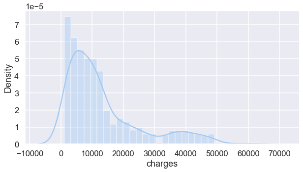

```python
plt.figure(figsize = (10,5))
sns.distplot(df_3['charges'])
```

#### By the looks of it, it is right tailed and it surely has outliers.

#### Let's define a function to find out the lower and the upper whisker using Z-Score method:

```python
def out_zscore(data):
    global outliers,zscore
    outliers = []
    zscore = []
    threshold = 3
    mean = np.mean(data)
    std = np.std(data)
    for i in data:
        z_score= (i - mean)/std
        zscore.append(z_score)
        if np.abs(z_score) > threshold:
            outliers.append(i)
    return print("Total number of outliers are",len(outliers))
```

```python
out_zscore(df_3.charges)
```

```
Total number of outliers are 7
```

### According to z-score method, it has 7 outliers

### Remedial Measure:

```python
#Data Frame without outliers
df_new = df_3[(df_3['charges'] < 3) | (df_3['charges'] > -3)]
```

```python
df_new
```

|  | age | sex | bmi | children | smoker | region | charges |
| --- | --- | --- | --- | --- | --- | --- | --- |
| 0 | 19 | female | 27.900 | 0 | yes | southwest | 16884.924000 |
| 1 | 18 | male | 33.770 | 1 | no | southeast | 1725.552300 |
| 2 | 28 | male | 33.000 | 3 | no | southeast | 4449.462000 |
| 3 | 33 | male | 22.705 | 0 | no | northwest | 21984.470610 |
| 4 | 32 | male | 28.880 | 0 | no | northwest | 3866.855200 |
| 5 | 31 | female | 25.740 | 0 | no | southeast | 3756.621600 |
| 6 | 46 | female | 33.440 | 1 | no | southeast | 8240.589600 |
| 7 | 37 | female | 27.740 | 3 | no | northwest | 7281.505600 |
| 8 | 37 | male | 29.830 | 2 | no | northeast | 6406.410700 |
| 9 | 60 | female | 25.840 | 0 | no | northwest | 28923.136920 |
| 10 | 25 | male | 26.220 | 0 | no | northeast | 2721.320800 |
| 11 | 62 | female | 26.290 | 0 | yes | southeast | 27808.725100 |
| 12 | 23 | male | 34.400 | 0 | no | southwest | 1826.843000 |
| 13 | 56 | female | 39.820 | 0 | no | southeast | 11090.717800 |
| 14 | 27 | male | 42.130 | 0 | yes | southeast | 39611.757700 |
| 15 | 19 | male | 24.600 | 1 | no | southwest | 1837.237000 |
| 16 | 52 | female | 30.780 | 1 | no | northeast | 10797.336200 |
| 17 | 23 | male | 23.845 | 0 | no | northeast | 2395.171550 |
| 18 | 56 | male | 40.300 | 0 | no | southwest | 10602.385000 |
| 19 | 30 | male | 35.300 | 0 | yes | southwest | 36837.467000 |
| 20 | 60 | female | 36.005 | 0 | no | northeast | 13228.846950 |
| 21 | 30 | female | 32.400 | 1 | no | southwest | 4149.736000 |
| 22 | 18 | male | 34.100 | 0 | no | southeast | 1137.011000 |
| 23 | 34 | female | 31.920 | 1 | yes | northeast | 37701.876800 |
| 24 | 37 | male | 28.025 | 2 | no | northwest | 6203.901750 |
| 25 | 59 | female | 27.720 | 3 | no | southeast | 14001.133800 |
| 26 | 63 | female | 23.085 | 0 | no | northeast | 14451.835150 |
| 27 | 55 | female | 32.775 | 2 | no | northwest | 12268.632250 |
| 28 | 23 | male | 17.385 | 1 | no | northwest | 2775.192150 |
| 29 | 31 | male | 36.300 | 2 | yes | southwest | 38711.000000 |

[output cut: 1308 more lines]

# Covariance, Pearson correlation between two columns

```python
#import libraries
import numpy as np
import pandas as pd #for DataFrame
from scipy import stats #for pearson correlation
```

```python
list_1 = {'H': pd.Series([34,76,21,98,12,98,55,76,22,43]),
          'W': pd.Series([65,32,77,87,54,22,90,78,65,33]),
          'Marks':pd.Series([56,76,34,78,56,76,98,76,87,46]),
         }
list_1 = pd.DataFrame(list_1)
list_1
```

|  | H | W | Marks |
| --- | --- | --- | --- |
| 0 | 34 | 65 | 56 |
| 1 | 76 | 32 | 76 |
| 2 | 21 | 77 | 34 |
| 3 | 98 | 87 | 78 |
| 4 | 12 | 54 | 56 |
| 5 | 98 | 22 | 76 |
| 6 | 55 | 90 | 98 |
| 7 | 76 | 78 | 76 |
| 8 | 22 | 65 | 87 |
| 9 | 43 | 33 | 46 |

```python
covariance = list_1.cov(min_periods=None)
covariance
```

|  | H | W | Marks |
| --- | --- | --- | --- |
| H | 1026.277778 | -104.944444 | 297.277778 |
| W | -104.944444 | 587.122222 | 100.900000 |
| Marks | 297.277778 | 100.900000 | 386.677778 |

A positive covariance means that the two variables at hand are positively related, and they move in the same direction.

A negative covariance means that the variables are inversely related, or that they move in opposite directions.

```python
list_of_H = list_1['H']
```

```python
list_of_W = list_1['W']
list_of_Marks = list_1['Marks']
```

```python
corr = stats.pearsonr(list_of_H,list_of_W)
```

```python
print('Correlation between H and W column: ',corr)
```

```
Correlation between H and W column:  (-0.1351956540057606, 0.7096059889606499)
```

```python
corr_1 = stats.pearsonr(list_of_H,list_of_Marks)
print('Correlation between H and Marks column: ',corr_1)
```

```
Correlation between H and Marks column:  (0.47190586646503624, 0.1685046707330148)
```

```python
corr_2 = stats.pearsonr(list_of_W,list_of_Marks)
print('Correlation between W and Marks column: ',corr_2)
```

```
Correlation between W and Marks column:  (0.21176408203208358, 0.5569863785951487)
```

```python
flights
```

[output not shown]

144 rows × 3 columns

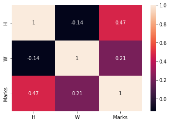

```python
import seaborn as sns
#plotting the heatmap for correlation
ax = sns.heatmap(list_1.corr(), annot=True)
```

```python
import pandas as pd
```

# Z-stat vs T-stat

**Z-tests**

- With the help of z-score, we can come to know how far the data point is from the mean in the standard deviation. A z-test compares a sample to a defined population and is typically used for dealing with problems relating to larger samples (n > 30). Z-score can also be used to test the hypothesis, and if the standard deviation is known, then it is beneficial.

**T-tests**

- Similar to the z-tests, t-tests are also used to test a hypothesis, but it is most useful when there is a need to know the significant difference between 2 independent sample groups.
- In other words, the t-test asks whether the difference between the means of two groups is unlikely to have occurred because of the random chance. Usually, t-tests are the most appropriate when dealing with problems with a limited sample size (n < 30).

**When to use a t-tests vs. z-tests**

the t-test can be used when your sample:

- Has a sample size below 30,
- Has an unknown population standard deviation.

## Z-test and T-test

Question: Do height of me and my colleagues are statistically higher than population height?

#### Population

```python
df_popul = pd.read_csv('Height of Male and Female by Country 2022.csv')
df_popul.head(5)
```

|  | Rank | Country Name | Male Height in Cm | Female Height in Cm | Male Height in Ft | Female Height in Ft |
| --- | --- | --- | --- | --- | --- | --- |
| 0 | 1 | Netherlands | 183.78 | 170.36 | 6.03 | 5.59 |
| 1 | 2 | Montenegro | 183.30 | 169.96 | 6.01 | 5.58 |
| 2 | 3 | Estonia | 182.79 | 168.66 | 6.00 | 5.53 |
| 3 | 4 | Bosnia and Herzegovina | 182.47 | 167.47 | 5.99 | 5.49 |
| 4 | 5 | Iceland | 182.10 | 168.91 | 5.97 | 5.54 |

```python
df_popul.drop(df_popul.columns[-2:], inplace=True, axis=1)
df_popul
```

|  | Rank | Country Name | Male Height in Cm | Female Height in Cm |
| --- | --- | --- | --- | --- |
| 0 | 1 | Netherlands | 183.78 | 170.36 |
| 1 | 2 | Montenegro | 183.30 | 169.96 |
| 2 | 3 | Estonia | 182.79 | 168.66 |
| 3 | 4 | Bosnia and Herzegovina | 182.47 | 167.47 |
| 4 | 5 | Iceland | 182.10 | 168.91 |
| ... | ... | ... | ... | ... |
| 194 | 195 | Mozambique | 164.30 | 155.42 |
| 195 | 196 | Papua New Guinea | 163.10 | 156.89 |
| 196 | 197 | Solomon Islands | 163.07 | 156.79 |
| 197 | 198 | Laos | 162.78 | 153.10 |
| 198 | 199 | Timor-Leste | 160.13 | 152.71 |

199 rows × 4 columns

```python
df_popul['Height in Cm'] = df_popul[df_popul.columns[-2:]].mean(axis=1)
df_popul
```

|  | Rank | Country Name | Male Height in Cm | Female Height in Cm | Height in Cm |
| --- | --- | --- | --- | --- | --- |
| 0 | 1 | Netherlands | 183.78 | 170.36 | 177.070 |
| 1 | 2 | Montenegro | 183.30 | 169.96 | 176.630 |
| 2 | 3 | Estonia | 182.79 | 168.66 | 175.725 |
| 3 | 4 | Bosnia and Herzegovina | 182.47 | 167.47 | 174.970 |
| 4 | 5 | Iceland | 182.10 | 168.91 | 175.505 |
| ... | ... | ... | ... | ... | ... |
| 194 | 195 | Mozambique | 164.30 | 155.42 | 159.860 |
| 195 | 196 | Papua New Guinea | 163.10 | 156.89 | 159.995 |
| 196 | 197 | Solomon Islands | 163.07 | 156.79 | 159.930 |
| 197 | 198 | Laos | 162.78 | 153.10 | 157.940 |
| 198 | 199 | Timor-Leste | 160.13 | 152.71 | 156.420 |

199 rows × 5 columns

```python
df_popul.dtypes
```

```
Rank                     int64
Country Name            object
Male Height in Cm      float64
Female Height in Cm    float64
Height in Cm           float64
dtype: object
```

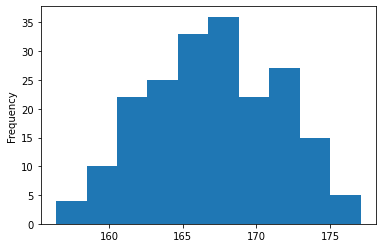

```python
df_popul['Height in Cm'].plot.hist()
```

```python
df_popul.describe()
```

|  | Rank | Male Height in Cm | Female Height in Cm | Height in Cm |
| --- | --- | --- | --- | --- |
| count | 199.000000 | 199.000000 | 199.000000 | 199.000000 |
| mean | 100.000000 | 173.089045 | 160.942915 | 167.015980 |
| std | 57.590508 | 4.949832 | 4.076377 | 4.432794 |
| min | 1.000000 | 160.130000 | 150.910000 | 156.420000 |
| 25% | 50.500000 | 169.490000 | 158.240000 | 163.892500 |
| 50% | 100.000000 | 173.530000 | 160.620000 | 166.995000 |
| 75% | 149.500000 | 176.510000 | 163.870000 | 170.355000 |
| max | 199.000000 | 183.780000 | 170.360000 | 177.070000 |

#### Sample (me and colleagues)

## Z-test

Let's generate 41-elems set of our possible heights. To be able to use Z-test

- population should be normally distributed
- the sample size must be quite large ($n>30$)
- elements in a sample are randomly drawn from a population

*https://dfrieds.com/math/z-tests.html*

```python
import numpy as np
```

```python
np.random.seed(0)
sample_range = np.random.randint(160, 180, size=41)
```

```python
df_sample = pd.DataFrame(sample_range)
df_sample.head(5)
```

|  | 0 |
| --- | --- |
| 0 | 172 |
| 1 | 175 |
| 2 | 160 |
| 3 | 163 |
| 4 | 163 |

```python
df_sample.describe()
```

|  | 0 |
| --- | --- |
| count | 41.000000 |
| mean | 170.073171 |
| std | 6.581756 |
| min | 160.000000 |
| 25% | 165.000000 |
| 50% | 169.000000 |
| 75% | 176.000000 |
| max | 179.000000 |

Let's summarize our data

```python
popul_std = round(df_popul.describe()['Height in Cm']['std'],2)
popul_mean = round(df_popul.describe()['Height in Cm']['mean'],2)
sample_std = round(df_sample.describe()[0]['std'],2)
sample_mean = round(df_sample.describe()[0]['mean'],2)
significance_lvl = 0.05
n = 41
```

```python
pd.Series(data={
    "popul_std": popul_std,
    "popul_mean": popul_mean,
    "sample_std": sample_std,
    "sample_mean": sample_mean,
    "significance_lvl": significance_lvl,
    "n": n,
    })
```

```
popul_std             4.43
popul_mean          167.02
sample_std            6.58
sample_mean         170.07
significance_lvl      0.05
n                    41.00
dtype: float64
```

## Z-test requirements:

1. Population's std and mean are known
2. Population are normally distributed
3. Sample size is greater than 30
4. Sample elements were drawn randomly from a population
5. Sample mean is known  
   All above are fullfilled.

### By hand

Hypothesis:  
$H_0 = \mu \leq 167.02$  
$H_1 = \mu > 167.02$ --> upper-tailed test

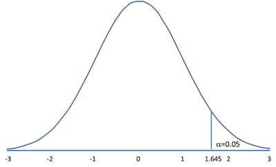

Default significance lvl = 95% --> $\alpha = 0.05$

$SSE$ = sum of squares error  
$Z_{statistic} = \frac{\overline{x}-\mu}{SSE}$ = $\frac{\overline{x}-\mu}{\frac{\sigma}{\sqrt{n}}}$ = $\frac{170.07-167.02}{4.43\div\sqrt{41}}=4.408$

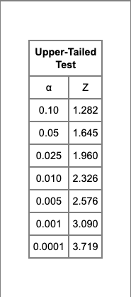

$Z_{critical} = 1.645$

*https://sphweb.bumc.bu.edu/otlt/mph-modules/bs/bs704_hypothesistest-means-proportions/bs704_hypothesistest-means-proportions3.html*

Since 4.408 is within the right range ($4.408>1.645$) we reject our $H_0$. It means that our average height is significant higher.

### With Python

```python
from scipy import stats
```

```python
sse = popul_std / np.sqrt(n)
z_score = (sample_mean - popul_mean)/sse
z_score
```

```
4.4084715404447135
```

```python
z_critical = (-1)*stats.norm.ppf(0.05)
z_critical
```

```
1.6448536269514729
```

### Answer:

Our average height is significant higher than population's height.

Now, let's consider smaller sample: 10-elems sized.

## T-test (One-sample)

```python
np.random.seed(0)
small_sample_range = np.random.randint(160, 180, size=10)

df_small_sample = pd.DataFrame(small_sample_range)
df_small_sample.head(5)
```

|  | 0 |
| --- | --- |
| 0 | 172 |
| 1 | 175 |
| 2 | 160 |
| 3 | 163 |
| 4 | 163 |

```python
df_small_sample.describe()
```

|  | 0 |
| --- | --- |
| count | 10.000000 |
| mean | 169.000000 |
| std | 6.733003 |
| min | 160.000000 |
| 25% | 163.250000 |
| 50% | 168.000000 |
| 75% | 174.250000 |
| max | 179.000000 |

```python
small_sample_mean = round(df_small_sample.describe()[0]['mean'],2)
small_sample_std = round(df_small_sample.describe()[0]['std'],2)
significance_lvl = 0.05
n = 10
```

```python
pd.Series(data={
    "popul_std": popul_std,
    "popul_mean": popul_mean,
    "small_sample_std": small_sample_std,
    "small_sample_mean": small_sample_mean,
    "significance_lvl": significance_lvl,
    "n": n,
    })
```

```
popul_std              4.43
popul_mean           167.02
small_sample_std       6.73
small_sample_mean    169.00
significance_lvl       0.05
n                     10.00
dtype: float64
```

## T-test requirements:

1. Population and sample are normally distributed.
2. Sample size is lower than 30
3. Population and sample variable is continuous.
4. Sample elements were drawn randomly from a population  
   All above are fullfilled.

https://dfrieds.com/math/intro-t-test-terms-and-one-sample-test.html

### By hand

Hypothesis:  
$H_0 = \mu \leq 167.02$  
$H_1 = \mu > 167.02$ --> upper-tailed test

Default significance lvl = 95% --> $\alpha = 0.05$

Standard Deviation of sample $s = \sqrt{\frac{\sum(x-\overline{x})^2}{n-1}}=6.73$  
Standard Error of mean $SE_{\overline{x}}=\frac{s}{\sqrt{n}}=\frac{6.73}{\sqrt{10}}=2.13$  
$t_{statistic} = \frac{\overline{x}-\mu}{SE_{\overline{x}}}$ = $\frac{169-167.02}{2.13}=0.93$

degrees of freedom = $df = n-1=9$  
$t_{critical} = 1.833$

*https://sphweb.bumc.bu.edu/otlt/mph-modules/bs/bs704_hypothesistest-means-proportions/bs704_hypothesistest-means-proportions3.html*

Since 0.93 is outside the right range ($0.93<1.833$) we fail to reject our $H_0$. It means that our average height isn't significant higher.

### With python

```python
t_score, p_value = stats.ttest_1samp(df_small_sample[0],
                                     popul_mean,
                                     alternative = 'greater')
t_score
```

```
0.9299430722614421
```

```python
t_critical = (-1)*round(stats.t.ppf(q=significance_lvl,
                                    df=n-1), 2)
t_critical
```

```
1.83
```

```python
p_value = round(p_value, 2)
```

```python
if p_value > significance_lvl:
    print(f"{p_value} > {significance_lvl}: fail to reject null hypothesis")
else:
    print(f"{p_value} < {significance_lvl}: reject null hypothesis")
```

```
0.19 > 0.05: fail to reject null hypothesis
```

We fail to reject $H_0$, so our height isn't significant higher, which is totally opposite answer against the one from Z-test.  
https://online.stat.psu.edu/statprogram/reviews/statistical-concepts/hypothesis-testing/p-value-approach

Let's check it for the same sample_std as in Z-test.

Standard Deviation of sample $s = \sqrt{\frac{\sum(x-\overline{x})^2}{n-1}}=6.58$  
Standard Error of mean $SE_{\overline{x}}=\frac{s}{\sqrt{n}}=\frac{6.58}{\sqrt{10}}=2.08$  
$t_{statistic} = \frac{\overline{x}-\mu}{SE_{\overline{x}}}$ = $\frac{170.07-167.02}{2.08}=1.47$

degrees of freedom = $df = n-1=9$  
$t_{critical} = 1.833$

*https://sphweb.bumc.bu.edu/otlt/mph-modules/bs/bs704_hypothesistest-means-proportions/bs704_hypothesistest-means-proportions3.html*

Since 1.47 is outside the right range ($1.47<1.833$) we fail to reject our $H_0$. It means that our average height isn't significant higher.

## Conslusion

Above case indicated that sample size play keys role in hypothesis testing.